# Capstone Milestone Report

Nicholas Smith

13 March 2016

## 0. Load Required Libraries

```r
#install.packages('tm')
#install.packages('RWeka')
#http://stackoverflow.com/questions/12872699/error-unable-to-load-installed-packages-just-now
library(tm)
```

```r
library(RWeka)
library(ggplot2)
```

## 1. Load the Data

```r
path <- "~/Documents/data-science/capstone/final/en_US"
newsData        <- readLines(paste(path,"/en_US.news.txt", sep = ''))
blogsData       <- readLines(paste(path,"/en_US.blogs.txt", sep = ''))
twitterData     <- readLines(paste(path,"/en_US.twitter.txt", sep = ''))
```

### Sample

These datasets are particularly large with 1010242, 899288 and 2360148 rows of data in the news, blogs and twitter data sets respectively.

In order to save resources I’m going to use a small sample of the data, 1%. This will allow me to get fast feedback loop while developing my application. Allowing me to try more things, without the need to process all the data everytime.

```r
sampleSize  <- 0.01
set.seed(1234)
newsSubSet  <- sample(newsData, length(newsData)*sampleSize)
blogsSubSet     <- sample(blogsData, length(blogsData)*sampleSize)
twitterSubSet   <- sample(twitterData, length(twitterData)*sampleSize)
sampleSet <- c(newsSubSet, blogsSubSet, twitterSubSet)
rm(blogsData, newsData, twitterData)
```

## 2. Clean the Data

### Profanity filtering

Here we remove the whole line that contains a dirty word rather than remove the words itself. Otherwise we will place words adjancent to one and other that would no normally be. This would adversly affect the prediction.

The regex uses [7 dirty words](https://en.wikipedia.org/wiki/Seven_dirty_words). They are as good a representation as any, without getting unessarily into what consititues a dirty work.

```r
sevenDirtyWord <- 'shit|piss|fuck|cunt|cocksucker|motherfucker|tits'
sampleProfanity <- grepl(sevenDirtyWord, sampleSet)
sampleSet <- sampleSet[! sampleProfanity]
```

We can see that from out sample there are 506 dirty words in the 1% sample corpus we have selected.

After we have taken away the obsene entries we’ll identify all the sentences. Creating a seperate entry for each as we will not want our n-grams to straddle a sentence termination.

### Tidy the data

We’re also going to strip out all other non alpha characters and tidy up the white space that processing creates.

```r
sampleSet <- unlist(strsplit(sampleSet,"[\\.]|[?]|[!]"))
sampleSet <- gsub("[^[:alpha:] ]", "", sampleSet)
sampleSet <- gsub("^\\s+", "", sampleSet)
sampleSet <- gsub("\\s+$", "", sampleSet)
sampleSet <- gsub("\\s+", " ", sampleSet)
sampleSet <- sampleSet[sampleSet != ""]
```

What about single apostrophes? Well we could do something more clever with these, i.e. word steming or expand to the full word. We can perhaps look at that in the future when refining and tuning our application.

### 3. Exploritory analysis

Until now we have been treating the data as text in vectors, we will convert the data to a Corpus class from the `tm` package to probe the data in interesting ways. We use a significantly lower `lowfreq` term for bigrams as they inherently occur less frequently.

```r
options(mc.cores=1)
sampleCorpus <- Corpus(VectorSource(sampleSet))
unigramFunc = function(x) NGramTokenizer(x, Weka_control(min = 1, max = 1))
bigramFunc = function(x) NGramTokenizer(x, Weka_control(min = 2, max = 2))

unigram = TermDocumentMatrix(sampleCorpus, control = list(tokenize = unigramFunc))
bigram = TermDocumentMatrix(sampleCorpus, control = list(tokenize = bigramFunc))

unigramfreqTerms = findFreqTerms(unigram, lowfreq = 3000)
bigramfreqTerms = findFreqTerms(bigram, lowfreq = 750)

unigramFreq = rowSums(as.matrix(unigram[unigramfreqTerms,]))
unigramFreq = data.frame(unigram=names(unigramFreq), Frequency=unigramFreq)

bigramFreq = rowSums(as.matrix(bigram[bigramfreqTerms,]))
bigramFreq = data.frame(bigram=names(bigramFreq), Frequency=bigramFreq)
```

No we have constructed data frames of our unigram and bigram results we can have a look at the most used single words in our corpus:

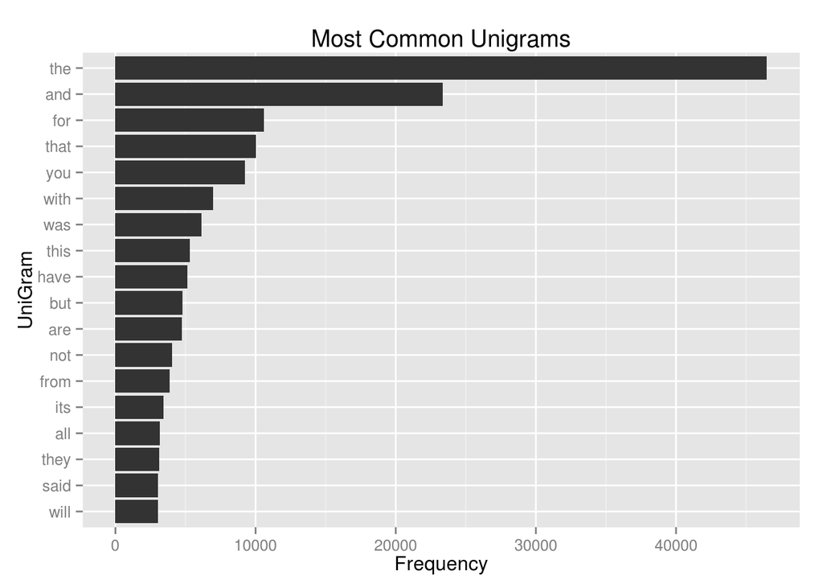

```r
ggplot(unigramFreq, aes(x=reorder(unigram, Frequency), y=Frequency)) +
    geom_bar(stat = "identity") +  coord_flip() +
    xlab("UniGram") + ylab("Frequency") +
    labs(title = "Most Common Unigrams")
```

The most popular bi grams in our corpus are:

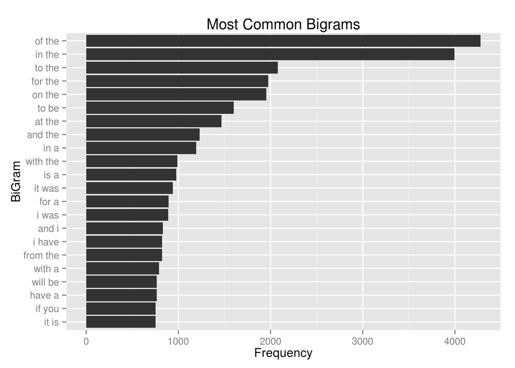

```r
ggplot(bigramFreq, aes(x=reorder(bigram, Frequency), y=Frequency)) +
    geom_bar(stat = "identity") +  coord_flip() +
    xlab("BiGram") + ylab("Frequency") +
    labs(title = "Most Common Bigrams")
```